# MCMC_HW_Elting

Rosalee Elting

2023-02-07

# 1 Generating Fake Data

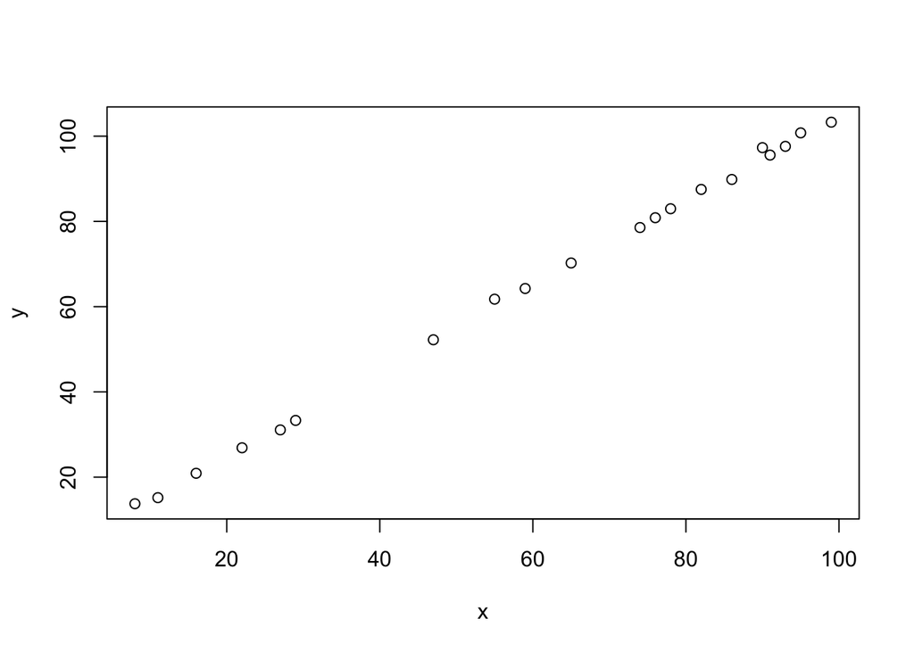

```r
# I want my data points to range from 5 to 100.
set.seed(100)
#making a range of values that x could be pulled from.
range <- seq(from=5, to =100, by =1)
#taking a subset of range values for x
x <- sample(x= range, size =20)
#variables of the regression of my fake data
slope <- 1
intercept <- 5
#assigning y values for these x's
y <- intercept + slope*x + rnorm(n=20, mean =0, sd =1)
plot(x,y)
```

# 2 Create a Function for Posterior Probability of a Linear Regression

P[1] equals intecept, P[2] is slope and P[3] is error term

```r
regpost <- function(P, x, y) {
    yhat <- P[1] + P[2] *x
    prior <-  sum(dnorm(P[1], mean =0, sd=10, log=TRUE),
              dnorm(P[2], mean=0, sd=10, log=TRUE),
              dnorm(P[3], mean=0, sd=1, log=TRUE))
        #sum is positive here, we're maximizing the log likelihood
    like <-  sum(dnorm(y, mean = yhat, sd = exp(P[3]), log= TRUE))
    post <- like+prior
    return(post)
}
```

# 3 Testing my Function with my faked data as test of function before proceeding

```r
P = c(3,1,1)
prob <- regpost(P= P, x=x, y=y)
print(prob)
```

```
## [1] -52.93305
```

This produced a negative number that is proportional to the probability, not the true probability.

# 4 Running a MCMC code

I am running this code with a chain of 10,000 iterations of the loop, making estimates for all three of the parameters in my linear regression.  
**A few notes:**

I’m making a matrix, called chain, that will take 10000 steps with three columns for intercept, slope and error parameters, respectively.

I assign the first rows of chain as all zeros, giving the loop one set of values to start with.

I create a single starting normally distributed value for each parameter, using the previous chain value for that paramerer as the mean, and the scale as a standard deviation. These are called intercept, slope and error and all represent **Pstar** for that parameter

I then calculate the probability given my data, or [theta | y] using my regpost function, with the above pstar for each parameter as input. this is the poststar line.

I then calculate the probability of [y | theta ] based on the previous estimate in chain and my data. this is called postchain.

I then compare the ratio of my proposed parameter values (poststar) and the previous values in the chain (postchain). I compare these with a number from a random uniform distribution.

Here I test for this row in a chain, for every parameter, if my ratio of proposed-previous parameters are greater or less than the rprob I got in the Monte Carlo step. If the ratio is larger, I accept my pstar estiamte for each parameter, if it isn’t I paste the last value from the chain.

```r
steps <- 10000
scale <- 0.05

chain <- matrix(nrow = steps, ncol= 3)

chain[1,] <- c(0, 0, 0)

for (i in 2: length(chain[,1])) {

  intercept <- rnorm(n = 1, mean = chain[i-1,1], sd= scale)
  slope <- rnorm(n = 1, mean = chain[i-1,2], sd= scale)
  error <- rnorm(n = 1, mean = chain[i-1,3], sd= scale)
  params <- c(intercept, slope, error)

    poststar <- regpost(P = params, x, y)

    postchain <- regpost(P = chain[i-1,], x, y)

    R <- exp(poststar - postchain)

    Rprob <- runif(1)
#don't use ifelse() here! It will break it.
    chain[i,] <- if (R < Rprob){chain[i-1,]} else{c(intercept, slope, error)}

}
```

# 5 Acceptance and Plotting

Here I report the acceptance rates for my parameters (the values are all the same, since I accept or reject row-wise). Depending on the reporting of these acceptance rates, I could change scale if needed to make sure that acceptance is between 0.2 and 0.4.

```r
#reporting acceptance for each column individually
intercept_acceptance <- 1- mean(duplicated(chain[,1]))
slope_acceptance <- 1- mean(duplicated(chain[,2]))
error_acceptance <- 1- mean(duplicated(chain[,3]))

#printing these acceptance rates
print(intercept_acceptance)
```

```
## [1] 0.1194
```

```r
print(slope_acceptance)
```

```
## [1] 0.1194
```

```r
print(error_acceptance)
```

```
## [1] 0.1194
```

# 6 Plot Chain Output of all thee parameters individually

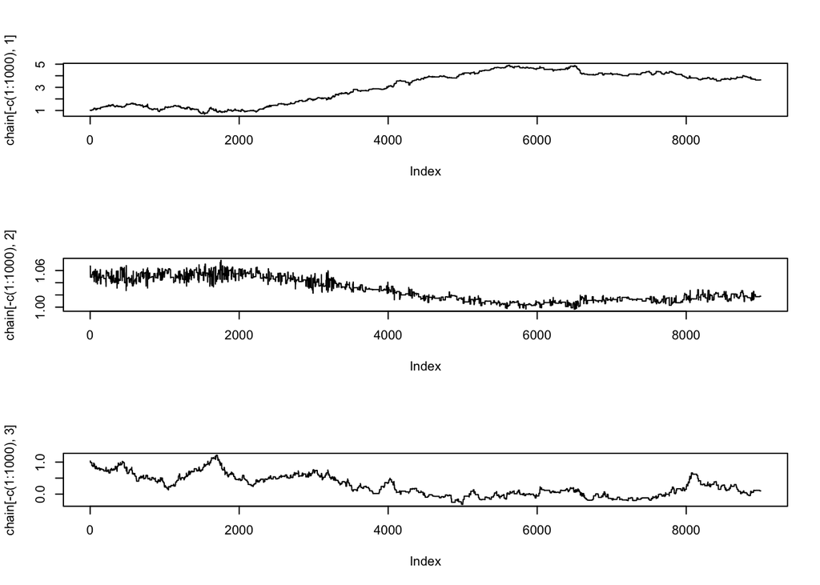

```r
#plotting all parameters from the model; ommitting burn in
par(mfrow=c(3,1))
plot(chain[-c(1:1000),1], type='l')
plot(chain[-c(1:1000),2], type='l')
plot(chain[-c(1:1000),3], type='l')
```

# 7 Plot the marginal distribution of the intercept and slope

Here I will plot the marginal distribution of each parameter, as well as utilize quantile estimates to produce 95% credible interval of the slope and intercept parameters.

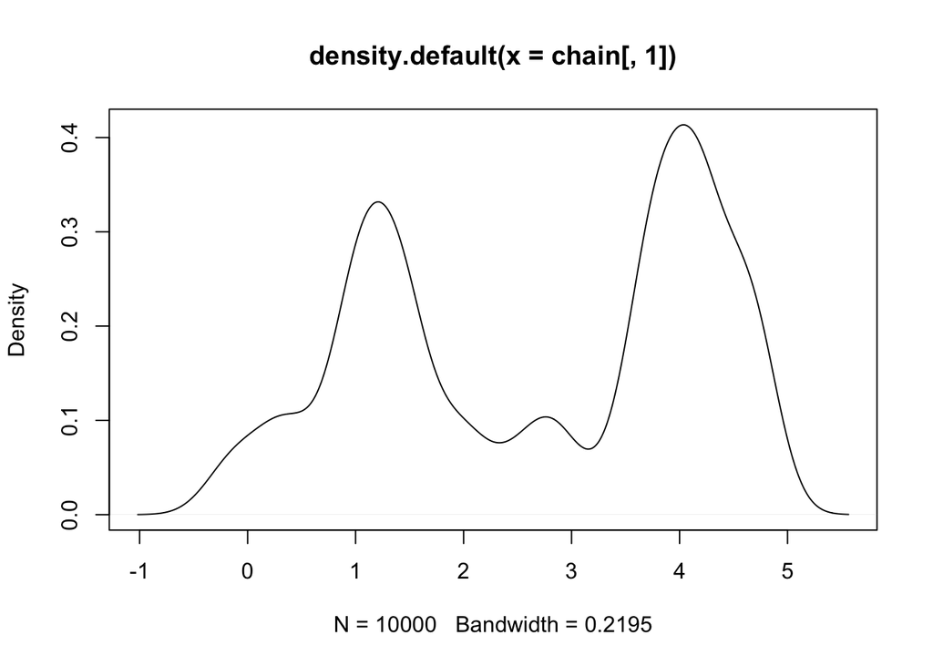

```r
plot(density(chain[,1]))
```

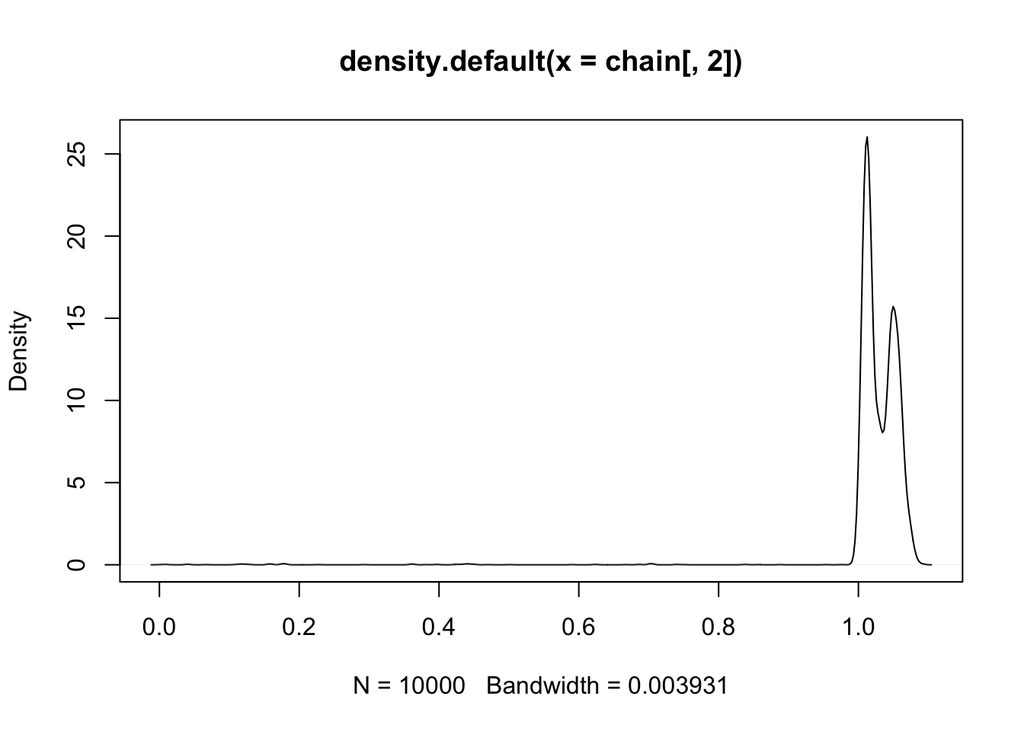

```r
plot(density(chain[,2]))
```

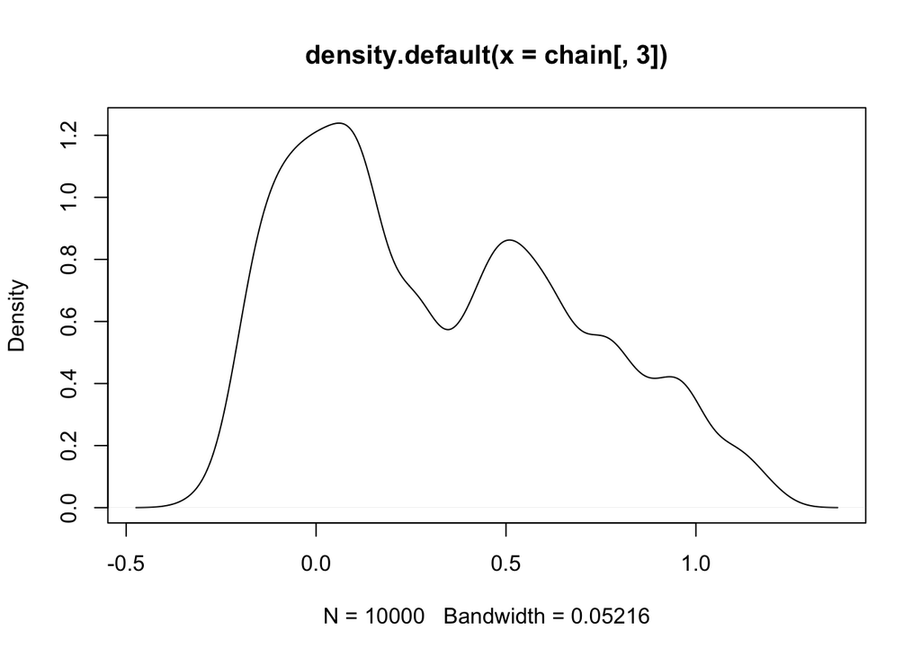

```r
plot(density(chain[,3]))
```

```r
intercept_95_cred <- NA
intercept_95_cred <- c(quantile(chain[,1], c(0.025)), quantile(chain[,1], c(0.975)))
slope_95_cred <- NA
slope_95_cred <- c(quantile(chain[,2], c(0.025)) , quantile(chain[,2], c(0.975)))

print(intercept_95_cred)
```

```
##        2.5%       97.5%
## -0.04920067  4.78341550
```

```r
print(slope_95_cred)
```

```
##     2.5%    97.5%
## 1.002638 1.070678
```

# 8 Plot the joint distribution of the intercept and slope

Plotting the intercept as x, and slope as y post burn-in

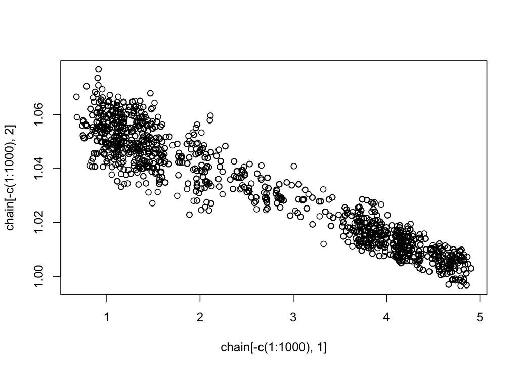

```r
plot(x= chain[-c(1:1000),1], y= chain[-c(1:1000),2])
```

# Comparing with Canned Function Using the linear model estimates from R to see how my estimates from MCMC compare with R’s.

```r
canned <- lm(y~x)
summary(canned)
```

```
##
## Call:
## lm(formula = y ~ x)
##
## Residuals:
##      Min       1Q   Median       3Q      Max
## -1.29274 -0.60029 -0.08165  0.26979  2.16156
##
## Coefficients:
##             Estimate Std. Error t value Pr(>|t|)
## (Intercept) 4.839703   0.441248   10.97 2.12e-09 ***
## x           1.003434   0.006551  153.18  < 2e-16 ***
## ---
## Signif. codes:  0 '***' 0.001 '**' 0.01 '*' 0.05 '.' 0.1 ' ' 1
##
## Residual standard error: 0.8882 on 18 degrees of freedom
## Multiple R-squared:  0.9992, Adjusted R-squared:  0.9992
## F-statistic: 2.346e+04 on 1 and 18 DF,  p-value: < 2.2e-16
```

# 9 Calculate a T-based confidence interval

Calculating for the slope of the canned solution, “canned”

```r
confint(canned, 'x' , level= 0.95)
```

```
##       2.5 %   97.5 %
## x 0.9896714 1.017196
```

# 10 Mess with Priors

I am making a second function with different priors

```r
#changing all priors to have a sd of 1
priortest <- function(P, x, y) {
    yhat <- P[1] + P[2] *x
    prior <-  sum(dnorm(P[1], mean =0, sd=1, log=TRUE),
              dnorm(P[2], mean=0, sd=1, log=TRUE),
              dnorm(P[3], mean=0, sd=1, log=TRUE))
        #sum is positive here, we're maximizing the log likelihood
    like <-  sum(dnorm(y, mean = yhat, sd = exp(P[3]), log= TRUE))
    post <- like+prior
    return(post)
}

#P[1] equals intecept, P[2] is slope and P[3] is error term
steps <- 10000
scale <- 0.05

chain2 <- matrix(nrow = steps, ncol= 3)

chain2[1,] <- c(0, 0, 0)

for (i in 2: length(chain2[,1])) {

  intercept <- rnorm(n = 1, mean = chain2[i-1,1], sd= scale)
  slope <- rnorm(n = 1, mean = chain2[i-1,2], sd= scale)
  error <- rnorm(n = 1, mean = chain2[i-1,3], sd= scale)
  params <- c(intercept, slope, error)

    poststar <- priortest(P = params, x, y)

    postchain2 <- priortest(P = chain2[i-1,], x, y)

    R <- exp(poststar - postchain2)

    Rprob <- runif(1)

    chain2[i,] <- if (R < Rprob){chain2[i-1,]} else{c(intercept, slope, error)}

}
intercept_acceptance_2 <- 1- mean(duplicated(chain2[,2]))
print(intercept_acceptance_2)
```

```
## [1] 0.1207
```

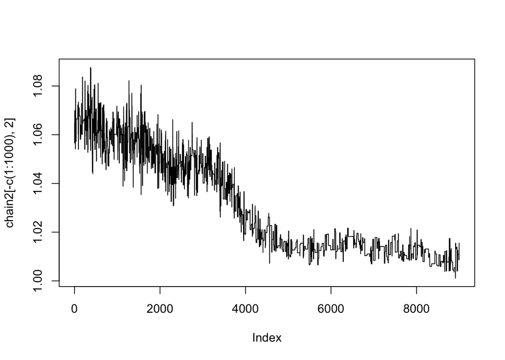

```r
plot(chain2[-c(1:1000),2], type='l')
```

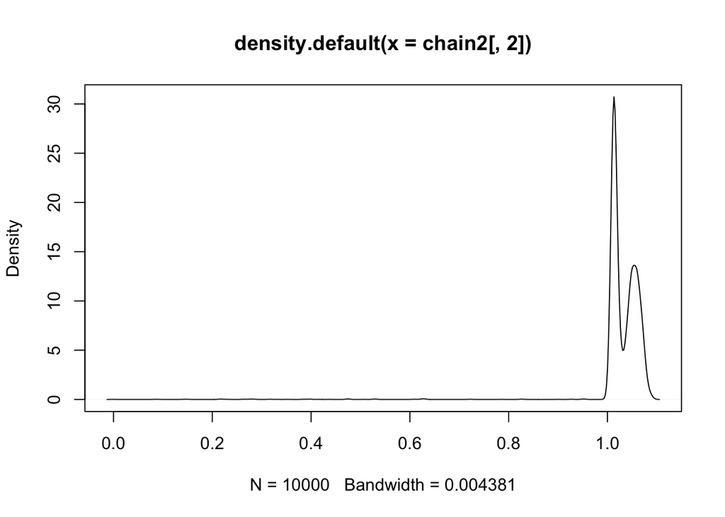

```r
plot(density(chain2[,2]))
```

```r
slope_95_cred_2 <- NA
slope_95_cred_2 <- c(quantile(chain2[,2], c(0.025)) , quantile(chain2[,2], c(0.975)))

print(slope_95_cred_2)
```

```
##     2.5%    97.5%
## 1.006159 1.075327
```